# Review of Data

London East Asia Film Festival (LEAFF) 2017

[Avision Ho](https://github.com/avisionh)

2018-09-11

# Executive Summary

[figure not shown]

From the data analysed in this report, the key findings are:

**The curated film programme at LEAFF 2017 catered to a mainstream and large audience, and more particularly, being of most interest to the key age groups of 20 - 30.**

**The marketing strategy attracted a good range of people from different backgrounds who were new to the festival and returned to the festival from previous years.**

**The additional events such as Q&A sessions and workshops successfully engaged audiences enough to develop their interest and intrigue in film beyond just watching film.**

**The overall delivery of the entire festival was effective in receiving positive reviews from attendees.**

**Lastly, the overall festival experience was of such quality that 92% of survey respondents will return again in the future.**

# Introduction

> *LEAFF aims to champion the growing collaboration in East Asian filmmaking with a philosophy that marks a shift in the cinematic landscape of East Asia, and moves away from cultural and cinematic borders. Our vision is to bring a much wider, eclectic, and diverse programme of films from over 10 countries to show the richness and diversity of the region and its people. We want to draw people in with the familiar, and offer opportunities to see something new.*

This paper analyses the data collected from the London East Asia Film Festival (LEAFF) 2017. It does so with the intention of providing a summary of how successful the event was, and to provide a benchmark for future editions of LEAFF.

# Section 1: General Information

This section presents a general high-level overview of the film shown and where they were screened.

## Section 1.1: Films Shown and Locations

- For the 2017 festival a wide range of films from different nations that included South Korea, Japan, Hong Kong, Vietnam, and the Phillippines were shown. These included The Fortress (2017), Love Off The Cuff (2017), V.I.P. (2017), Bhoy Instik (2017), End of April (2016).

  [Full programme here](https://www.leaff.org.uk/programme-2/)
- The screenings for these films took place in a variety of locations, mostly in London, but with a few in other regions in the UK. These included Odeon Leicester Square, Odeon Tottenham Court Road, Empire Haymarket, Sheffield Showroom.

## Section 1.2: Accessibility

- For each of these film screenings, all of them were an **accessibility screening**. Of those that were an **accessbility screening**, all of them had descriptive subtitles and/or were captioned.

## Section 1.3: Additional Events

- Beyond showing films, LEAFF 2017 offered audiences the chance to be more involved with films and cinema by hosting a series of events to accompany some of the festival’s film screenings. These events involved sessions such as Q&A, Introduction, Panel Discussion, Talk.

## Section 1: Summary

Given the range of films screened, the way these screenings met accessibility requirements, and the additional events that were hosted during the festival to complement the films, then LEAFF 2017 offered all audiences an eclectic range of activities and films to enjoy.

# Section 2: Audience Demographics

This section presents data on the demographics of people who have attended LEAFF 2017, and filled in our post-screening surveys.

## Section 2.1: Gender

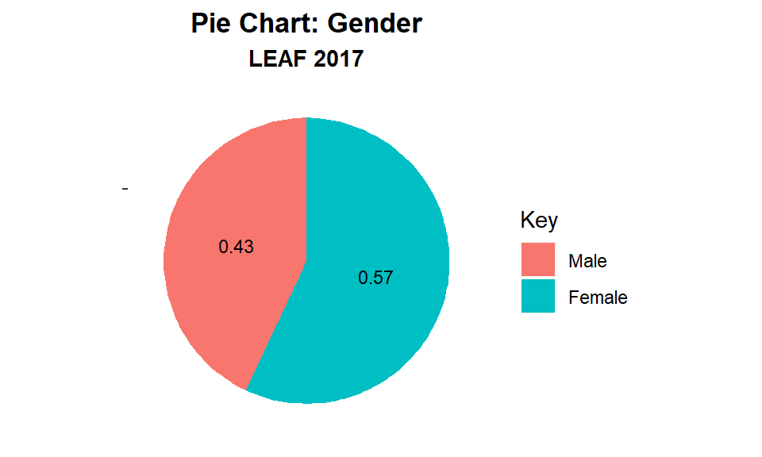

Figure 1

- In **Figure 1**, the female-to-male proportion of audience who went to the film screenings during the festival and completed this field in the post-film survey is similar, 57% to 43%.

## Section 2.2: Age

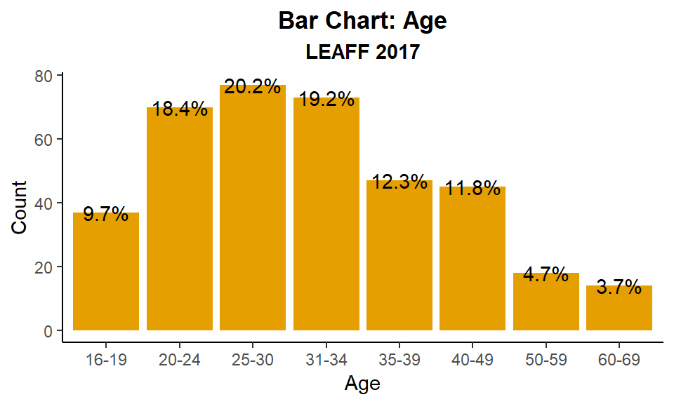

Figure 2

- In **Figure 2**, the largest three age groups for our audience who went to the film screenings during the festival and completed this field in the post-film survey are the 25-30, 31-34, 20-24 categories.
- This ties in with the festival’s aim to attract and engage young age groups in film and cinema, as it is the young age groups who will be the future consumers of film and cinema.

## Section 2.3: Ethnicity

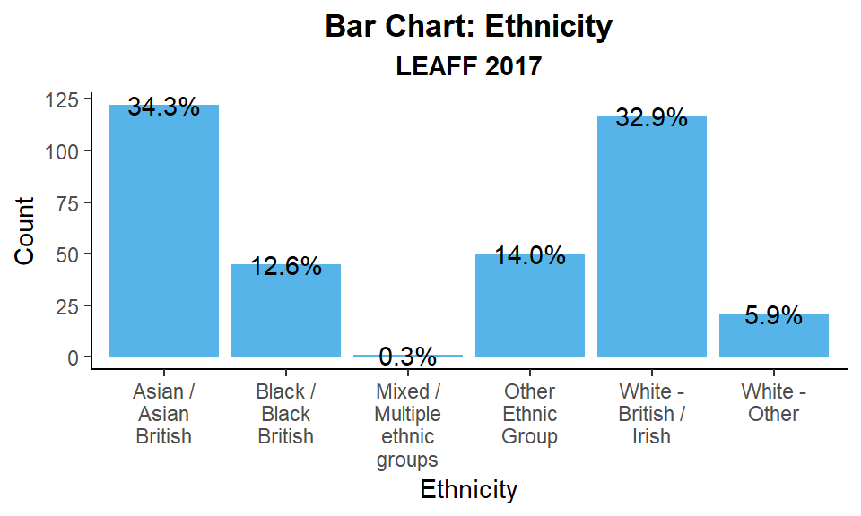

Figure 3

- In **Figure 3**, the largest three ethnicity groups for our audience who went to the film screenings during the festival and completed this field in the post-film survey are Asian / Asian British, White - British / Irish, Other Ethnic Group.

*This would appeal most to sponsors who want to improve their brand exposure to different ethnic groups.*

- Notice in particular that the number of *Asian / Asian British (122)* and *White - British / Irish (117)* ethnic groups who attended LEAFF 2017 are very close. This demonstrates that the film festival is effective in appealing to both an East Asian and non-East Asian audiences.

## Section 2: Summary

Given the relatively equal split between genders, the popularity of the festival with younger age groups, and the festival’s ability to attract both East Asian and non-East Asian ethnic groups, LEAFF 2017 was effective in catering to the key audience group of younger adults equally between genders, and within this subgroup, attracting a wide range of people from different ehtnic backgrounds.

# Section 3: Key Performance Metrics

This section presents key analyis of the festival’s performance data.

## Section 3.1: Total admissions for each film

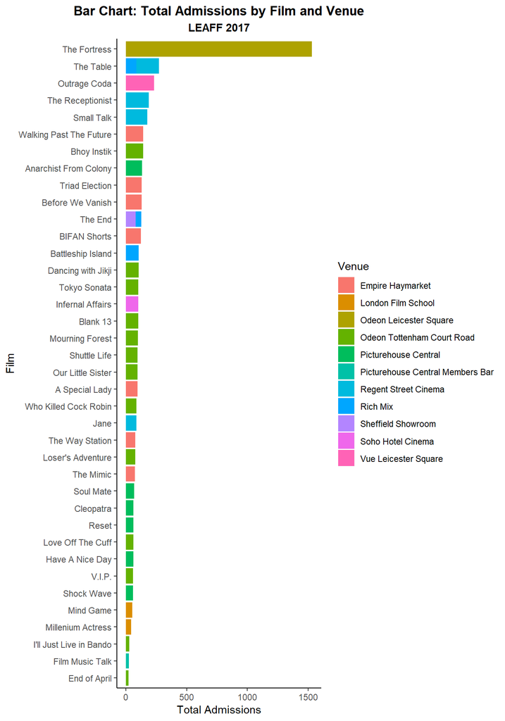

Figure 4

- In **Figure 4**, we have the number of people who bought tickets for each of the film screenings, with the colour-coding distinguishing which films were shown in which cinemas. In particular, it is worth noting that the most-watched film, *The Fortress*, was held at *Odeon Leicester Square*, which has a screen capacity of *1679*; whereas the other cinemas where films were shown have much smaller capacities.
- The table below focusses on the key insight of the most popular films that can be drawn from **Figure 4**. Whilst we do not possess data on the seating capacity for each venue, and consequently cannot make a more accurate inference on which films sold the most tickets relative to the number of tickets available, we do know that for opening gala film, *The Fortress*, 91.19% of available tickets were sold.

*The most popular films by admissions for LEAFF 2017*

| Film | Release Year | Venue | Total Admissions |
| --- | --- | --- | --- |
| The Fortress | 2017 | Odeon Leicester Square | 1531 |
| The Table | 2016 | Regent Street Cinema | 271 |
| Outrage Coda | 2017 | Vue Leicester Square | 230 |
| The Receptionist | 2016 | Regent Street Cinema | 187 |
| Small Talk | 2016 | Regent Street Cinema | 175 |

## Section 3.2: Retaining old audiences and capturing new audiences

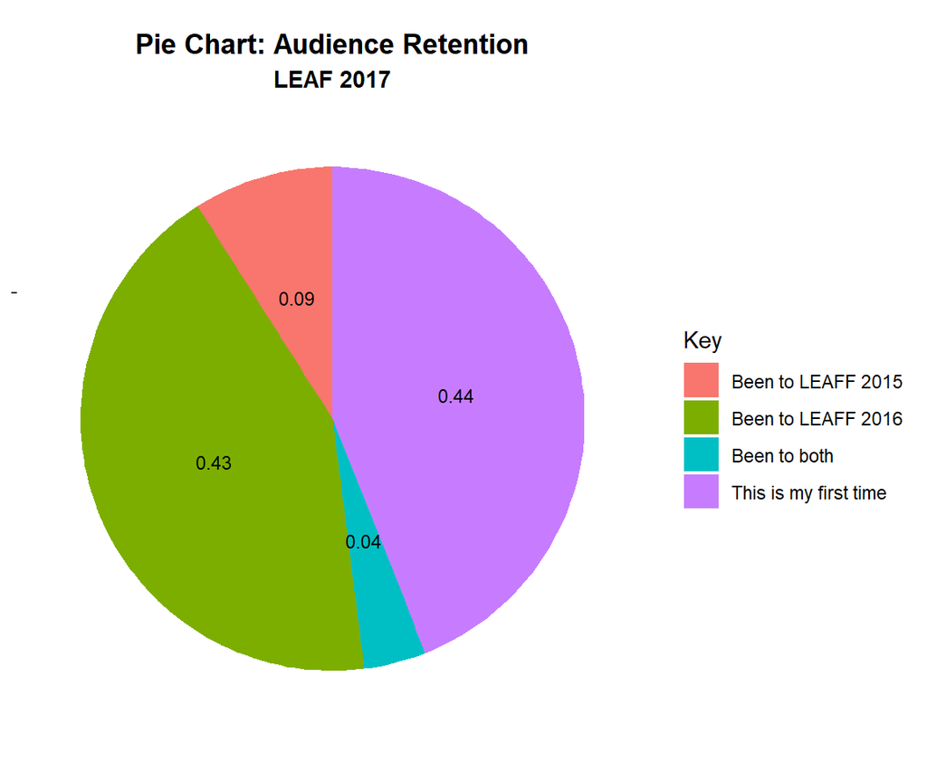

Figure 5

- In **Figure 5**, we have 172 of LEAFF 2017 attendees saying “This is my first time” and 170 of LEAFF 2017 attendees saying “Been to LEAFF 2016”.
- These were the top two responses and demonstrates that LEAFF 2017’s marketing strategy was effective in encouraging attendees from 2016 to return to LEAFF 2017 and in attracting new attendees.

## Section 3.3: Audience rating of their LEAFF 2017 experience

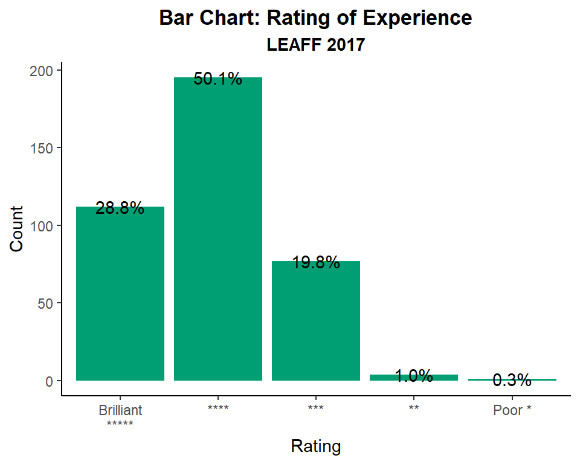

Figure 6

- In **Figure 6**, 79% of attendees rated their LEAFF 2017 experience as being either **Brilliant ******* (*five stars*) or **Good ****** (*four stars*).
- This demonstrates that the majority of attendees enjoyed LEAFF 2017 and that the programme and activities which were part of this were successful in capturing the public’s interests and appetite for film and cinema.

## Section 3.4: Audience main motivation for attending

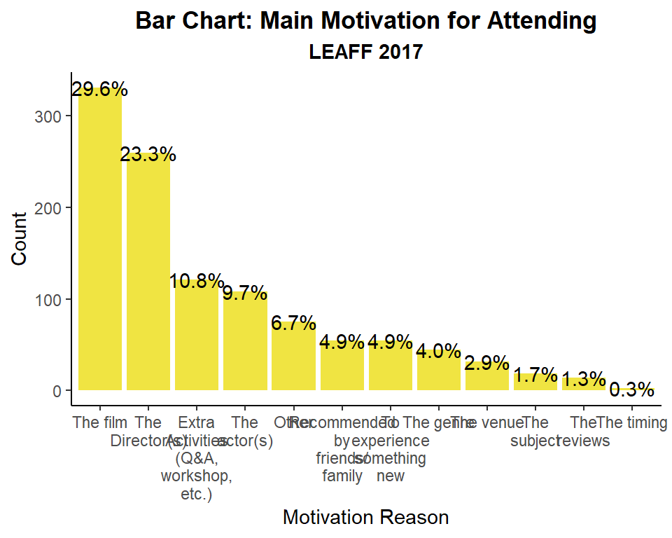

Figure 7

- In **Figure 7**, the main reasons most people attended were The Director(s), Extra Activities (Q&A, workshop, etc.), The film, The actor(s).

  *Main reasons* being defined as those reasons which have received more than 100 responses in the post-film survey.
- Indeed **Figure 7** complements **Figure 6** by providing the core reasons for why festival attendees gave such a positive response of their LEAFF 2017 experience.
- **Figure 7** also demonstrates how diverse and far-reaching the reasons for why people attend the festival are, thereby illustrating that the festival caters for a number of preferences, tastes and interests. In this regard, LEAFF 2017 was able to engage with attendees on many levels.

## Section 3.5: Audience likelihood of attending future LEAFFs

- In the table below, 92% of respondents said they were either **Likely** or **Very Likely** to attend LEAFF in the future.

*Likelihood of audience returning for future LEAFF editions based on their experience of LEAFF 2017*

| Field | Value | Percent |
| --- | --- | --- |
| Very Likely | 150 | 38% |
| Likely | 209 | 53% |
| Don’t Know | 30 | 8% |
| Unikely | 1 | 0% |
| Definitely Not | 1 | 0% |

- This demonstrates that the festival was effective in encouraging people to watch more East Asian film and cinema.

## Section 3: Summary

- Given that a high and similar number of 172 of LEAFF 2017 attendees saying “This is my first time” and 170 of LEAFF 2017 attendees saying “Been to LEAFF 2016”, 79% of attendees rated their LEAFF 2017 experience as being either **Brilliant ******* (*five stars*) or **Good ****** (*four stars*) then this demonstrates that the festival was left a lasting impression on audiences such that 92% of respondents are either **Likely** or **Very Likely** to attend LEAFF in the future.

# Concluding Remarks

- From the data analysed in this report, the key findings are:

**The curated film programme at LEAFF 2017 catered to a mainstream and large audience, and more particularly, being of most interest to the key age groups of 20 - 30.**

**The marketing strategy attracted a good range of people from different backgrounds who were new to the festival and returned to the festival from previous years.**

**The additional events such as Q&A sessions and workshops successfully engaged audiences enough to develop their interest and intrigue in film beyond just watching film.**

**The overall delivery of the entire festival was effective in receiving positive reviews from attendees.**

**Lastly, the overall festival experience was of such quality that 92% of survey respondents will return again in the future.**